# P&S-2022: Lab assignment 2

Mariia Krasniukevych, Oleksandr Lykhanskyi, Lidiia Sokha

## General comments and instructions

- Complete solution will give you **4 points** (working code with explanations + oral defense). Submission deadline **November 1, 2023, 22:00**
- The report must be prepared as an *R notebook*; you must submit to **cms** both the source *R notebook* **and** the generated html file
- At the beginning of the notebook, provide a work-breakdown structure estimating efforts of each team member
- For each task, include
  - problem formulation and discussion (what is a reasonable answer to discuss);
  - the corresponding $\mathbf{R}$ code with comments (usually it is just a couple of lines long);
  - the statistics obtained (like sample mean or anything else you use to complete the task) as well as histograms etc to illustrate your findings;
  - justification of your solution (e.g. refer to the corresponding theorems from probability theory);
  - conclusions (e.g. how reliable your answer is, does it agree with common sense expectations etc)
- The **team id number** referred to in tasks is the **two-digit** ordinal number of your team on the list. Include the line **set.seed(team id number)** at the beginning of your code to make your calculations reproducible. Also observe that the answers **do** depend on this number!
- Take into account that not complying with these instructions may result in point deduction regardless of whether or not your implementation is correct.

### Task 1

#### In this task, we discuss the $[7,4]$ Hamming code and investigate its reliability. That coding system can correct single errors in the transmission of $4$-bit messages and proceeds as follows:

- given a message $\mathbf{m} = (a_1 a_2 a_3 a_4)$, we first encode it to a $7$-bit *codeword* $\mathbf{c} = \mathbf{m}G = (x_1 x_2 x_3 x_4 x_5 x_6 x_7)$, where $G$ is a $4\times 7$ *generator* matrix
- the codeword $\mathbf{c}$ is transmitted, and $\mathbf{r}$ is the received message
- $\mathbf{r}$ is checked for errors by calculating the *syndrome vector* $\mathbf{z} := \mathbf{r} H$, for a $7 \times 3$ *parity-check* matrix $H$
- if a single error has occurred in $\mathbf{r}$, then the binary $\mathbf{z} = (z_1 z_2 z_3)$ identifies the wrong bit no. $z_1 + 2 z_2 + 4z_3$; thus $(0 0 0)$ shows there was no error (or more than one), while $(1 1 0 )$ means the third bit (or more than one) got corrupted
- if the error was identified, then we flip the corresponding bit in $\mathbf{r}$ to get the corrected $\mathbf{r}^* = (r_1 r_2 r_3 r_4 r_5 r_6 r_7)$;
- the decoded message is then $\mathbf{m}^*:= (r_3r_5r_6r_7)$.

#### The **generator** matrix $G$ and the **parity-check** matrix $H$ are given by

$$G :=
\begin{pmatrix}
1 & 1 & 1 & 0 & 0 & 0 & 0 \\
1 & 0 & 0 & 1 & 1 & 0 & 0 \\
0 & 1 & 0 & 1 & 0 & 1 & 0 \\
1 & 1 & 0 & 1 & 0 & 0 & 1 \\
\end{pmatrix},
\qquad
H^\top := \begin{pmatrix}
1 & 0 & 1 & 0 & 1 & 0 & 1 \\
0 & 1 & 1 & 0 & 0 & 1 & 1 \\
0 & 0 & 0 & 1 & 1 & 1 & 1
\end{pmatrix}$$

#### Assume that each bit in the transmission $\mathbf{c} \mapsto \mathbf{r}$ gets corrupted independently of the others with probability $p = \mathtt{id}/100$, where $\mathtt{id}$ is your team number. Your task is the following one.

1. Simulate the encoding-transmission-decoding process $N$ times and find the estimate $\hat p$ of the probability $p^*$ of correct transmission of a single message $\mathbf{m}$. Comment why, for large $N$, $\hat p$ is expected to be close to $p^*$.
2. By estimating the standard deviation of the corresponding indicator of success by the standard error of your sample and using the CLT, predict the interval $(p^*-\varepsilon, p^* + \varepsilon)$, in which the estimate $\hat p$ falls with probability at least $0.95$.
3. What choice of $N$ guarantees that $\varepsilon \le 0.03$?
4. Draw the histogram of the number $k = 0,1,2,3,4$ of errors while transmitting a $4$-digit binary message. Do you think it is one of the known distributions?

#### You can (but do not have to) use the chunks we prepared for you

#### First, we set the **id** of the team and define the probability $p$ and the generator and parity-check matrices $G$ and $H$

```r
id <- 26

set.seed(id)
p <- id/100

# matrices G and H
G <- matrix(c(1, 1, 1, 0, 0, 0, 0,
        1, 0, 0, 1, 1, 0, 0,
        0, 1, 0, 1, 0, 1, 0,
        1, 1, 0, 1, 0, 0, 1), nrow = 4, byrow = TRUE)
H <- t(matrix(c(1, 0, 1, 0, 1, 0, 1,
        0, 1, 1, 0, 0, 1, 1,
        0, 0, 0, 1, 1, 1, 1), nrow = 3, byrow = TRUE))

#cat("The matrix G is: \n")
#G
#cat("The matrix H is: \n")
#H
#cat("The product GH must be zero: \n")
#(G%*%H)%%2
```

#### Next, generate the messages

```r
# generate N messages
N <- 1000

message_generator <- function(N) {
  matrix(sample(c(0,1), 4*N, replace = TRUE), nrow = N)
}

messages <- message_generator(N)
codewords <- (messages %*% G) %% 2
```

#### Generate random errors; do not forget that they occur with probability $p$! Next, generate the received messages

```r
errors <- matrix(rbinom(N*7, size = 1, prob = p), nrow = N)
received <- (codewords + errors) %% 2
```

The next steps include detecting the errors in the received messages, correcting them, and then decoding the obtained messages. After this, you can continue with calculating all the quantities of interest

1. Simulate the encoding-transmission-decoding process $N$ times and find the estimate $\hat p$ of the probability $p^*$ of correct transmission of a single message $\mathbf{m}$. Comment why, for large $N$, $\hat p$ is expected to be close to $p^*$.

```r
#First of all, we have to get syndrome z=rH(mod2) three-bites vector
syndrome <- function(r) as.vector((r %*% H) %% 2)

#Now we are correcting one message
correct_one  <- function(r) {
  z <- syndrome(matrix(r, nrow = 1))
  pos <- z[1] + 2*z[2] + 4*z[3]
  if (pos != 0) r[pos] <- 1 - r[pos]
  r
}

#decoding (leaving only bits with information)
decode_one   <- function(r) c(r[3], r[5], r[6], r[7])

#applying to all words
corrected <- t(apply(received, 1, correct_one))
decoded   <- t(apply(corrected, 1, decode_one))

#caclulating p_hat
success <- apply(decoded == messages, 1, all)
p_hat   <- mean(success)
p_hat
```

```
## [1] 0.398
```

We implement the Hamming $(7,4)$ decoder and estimate the success probability $\hat p$. For each received word $r\in\{0,1\}^7$ we compute the
$$z = rH \pmod{2}\in\{0,1\}^3,$$
which identifies a single-bit error via the position
$$\text{pos} = z_1 + 2z_2 + 4z_3.$$
If $\text{pos}\neq 0$, we flip $r_{\text{pos}}$ to obtain the corrected word $r^*$ and then decode the message as $m^*=(r^*_3,r^*_5,r^*_6,r^*_7)$. Finally, comparing $m^*$ to the original $m$ over $N$ trials, we set
$$\hat p=\frac{1}{N}\sum_{i=1}^{N}\mathbf
1\{m_i^*=m_i\}.$$

p* is the probability that the entire message is recovered correctly after encoding and decoding. For a Hamming (7,4) code, it is not equal to the bit error probability p. Since the code corrects any single-bit error, correctness occurs if there are 0 or 1 errors among the 7 transmitted bits.

$K = \{\text{the number of bit errors in the message}\}$

$p^* = \Pr\{\text{correct}\} = \Pr(K=0)+\Pr(K=1) = (1-p)^7 + 7p(1-p)^6$.

2. By estimating the standard deviation of the corresponding indicator of success by the standard error of your sample and using the CLT, predict the interval $(p^*-\varepsilon, p^* + \varepsilon)$, in which the estimate $\hat p$ falls with probability at least $0.95$.

```r
z <- qnorm(0.975)
SE <- sqrt(p_hat * (1 - p_hat) / N)
var_e <- z * SE
CI <- c(p_hat - var_e, p_hat + var_e)

list(SE = SE, epsilon = var_e, CI_for_p_star = CI)
```

```
## $SE
## [1] 0.01547889
##
## $epsilon
## [1] 0.03033806
##
## $CI_for_p_star
## [1] 0.3676619 0.4283381
```

From $N$ independent transmissions we estimate the success probability by
$$\hat
p=\frac{1}{N}\sum_{i=1}^N \mathbf{1}\{m_i^\*=m_i\}.$$
Its sampling uncertainty is measured by the standard error
$$SE=\sqrt{\frac{\hat p(1-\hat p)}{N}},$$
so, by the Central Limit Theorem, a two–sided $95\%$ confidence interval is
$$(\hat p-\varepsilon,\ \hat p+\varepsilon),\qquad
\varepsilon=1.96\,SE.$$

3. What choice of $N$ guarantees that $\varepsilon \le 0.03$?

```r
N_min <- ceiling((1.96^2 * 0.25) / 0.03^2)
N_min
```

```
## [1] 1068
```

Requiring $\varepsilon \le 0.03$ and solving for $N$ gives
$$1.96\sqrt{\frac{\hat p(1-\hat p)}{N}} \le 0.03
\;\Longrightarrow\;
N \ge \frac{1.96^{2}\,\hat p(1-\hat p)}{0.03^{2}}$$

4. Draw the histogram of the number $k = 0,1,2,3,4$ of errors while transmitting a $4$-digit binary message. Do you think it is one of the known distributions?

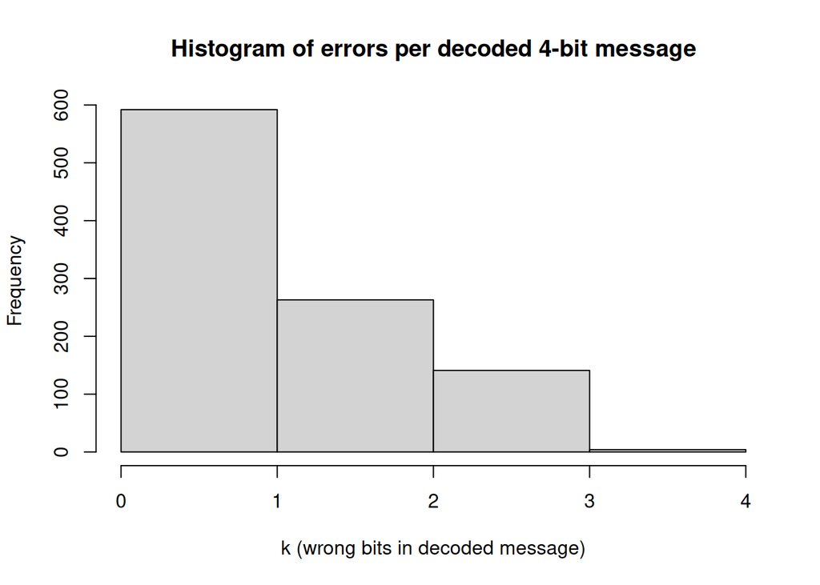

```r
k <- rowSums(decoded != messages)

hist(k, breaks = 0:4, xlab = "k (wrong bits in decoded message)",
     main = "Histogram of errors per decoded 4-bit message")
```

### Task 2.

In this task, we discuss a real-life process that is well modelled by a Poisson distribution. As you remember, a Poisson random variable describes occurrences of rare events, i.e., counts the number of successes in a large number of independent random experiments. One of the typical examples is the **radioactive decay** process.

Consider a sample of radioactive element of mass $m$, which has a big *half-life period* $T$; it is vitally important to know the probability that during a one second period, the number of nuclei decays will not exceed some critical level $k$. This probability can easily be estimated using the fact that, given the *activity* ${\lambda}$ of the element (i.e., the probability that exactly one nucleus decays in one second) and the number $N$ of atoms in the sample, the random number of decays within a second is well modelled by Poisson distribution with parameter $\mu:=N\lambda$. Next, for the sample of mass $m$, the number of atoms is $N = \frac{m}{M} N_A$, where $N_A = 6 \times 10^{23}$ is the Avogadro constant, and $M$ is the molar (atomic) mass of the element. The activity of the element, $\lambda$, is $\log(2)/T$, where $T$ is measured in seconds.

Assume that a medical laboratory receives $n$ samples of radioactive element ${{}^{137}}\mathtt{Cs}$ (used in radiotherapy) with half-life period $T = 30.1$ years and mass $m = \mathtt{team\, id \,number} \times 10^{-6}$ g each. Denote by $X_1,X_2,\dots,X_n$ the **i.i.d. r.v.**’s counting the number of decays in sample $i$ in one second.

```r
# To calculate lambda - activity of the element, according to our data, we use:
# Half life period (seconds)= Half life period (years) * 3,154*e+7
# Cesium_137 Molar atomic mass = 137
# Cesium_137 mass (according to initial conditions) = team_id(26) * 1e-6

cat("\n ======================================== \n")
cat("\n ===============SUBTASK 1================\n")
```

```
##
##  ===============SUBTASK 1================
```

```r
cat("\n ======================================== \n")
team_id <- 26

ln_2 <- log(2)
T_half_years <- 30.1
seconds_per_year <- 3.154e+7
N_Avogadro <- 6e+23

lambda <- ln_2 / (T_half_years * seconds_per_year) # activity of the given element

Ces_137_m <- team_id * 1e-6
Ces_137_M <- 137

N <- (Ces_137_m / Ces_137_M) * N_Avogadro
mu_single <- N * lambda # Poisson parameter for one sample Xi

cat("Calculated parameter of Poisson distribution of single sample Xi:", mu_single, "\n")
```

```
## Calculated parameter of Poisson distribution of single sample Xi: 83138332
```

```r
K <- 1e3
n <- 5

sample_values <- rpois(n*K, lambda = mu_single)

sample_means <- colMeans(matrix(sample_values, nrow=n))
```